# Self-Driving Car Engineer Nanodegree

## Project: Build a Traffic Sign Recognition Classifier

In this notebook, a template is provided for you to implement your functionality in stages, which is required to successfully complete this project. If additional code is required that cannot be included in the notebook, be sure that the Python code is successfully imported and included in your submission if necessary.

> **Note**: Once you have completed all of the code implementations, you need to finalize your work by exporting the iPython Notebook as an HTML document. Before exporting the notebook to html, all of the code cells need to have been run so that reviewers can see the final implementation and output. You can then export the notebook by using the menu above and navigating to \n", "**File -> Download as -> HTML (.html)**. Include the finished document along with this notebook as your submission.

In addition to implementing code, there is a writeup to complete. The writeup should be completed in a separate file, which can be either a markdown file or a pdf document. There is a [write up template](https://github.com/udacity/CarND-Traffic-Sign-Classifier-Project/blob/master/writeup_template.md) that can be used to guide the writing process. Completing the code template and writeup template will cover all of the [rubric points](https://review.udacity.com/#!/rubrics/481/view) for this project.

The [rubric](https://review.udacity.com/#!/rubrics/481/view) contains "Stand Out Suggestions" for enhancing the project beyond the minimum requirements. The stand out suggestions are optional. If you decide to pursue the "stand out suggestions", you can include the code in this Ipython notebook and also discuss the results in the writeup file.

> **Note:** Code and Markdown cells can be executed using the **Shift + Enter** keyboard shortcut. In addition, Markdown cells can be edited by typically double-clicking the cell to enter edit mode.

```python
import sys
sys.path.append("./src/")
```

```python
# %load ./src/TrafficSignData.py
import pickle
import numpy as np
import matplotlib.pyplot as plt


class TrafficSignData(object):
    def __init__(self, path="./data/", demo_mode=False):
        self.demo_mode = demo_mode
        self._load_data(path)
        if self.demo_mode:
            self._show_examples()
        self._extract_properties()
        self._normalize_input_data()
        self._balance_training_data()
        self._extract_properties()  # Repeat due to updated data.

    def _load_data(self, path):
        from os.path import join
        self.X_train, self.y_train = self._load_pickled_file(join(path, "train.p"))
        self.X_valid, self.y_valid = self._load_pickled_file(join(path, "valid.p"))
        self.X_test, self.y_test = self._load_pickled_file(join(path, "test.p"))

    def _load_pickled_file(self, file_path):
        with open(file_path, mode='rb') as f:
            data = pickle.load(f)
            return data['features'], data['labels']

    def _show_examples(self):
        """
        Show examples of each image class/label
        """
        labels, label_indices, label_counts = np.unique(self.y_train, return_index=True, return_counts=True)
        plt.figure(figsize=(15, 20))
        for idx in range(len(labels)):
            ax = plt.subplot(9, 5, idx + 1)
            ax.imshow(self.X_train[label_indices[idx]])
            ax.axis('off')
            ax.set_title(f"label {labels[idx]}: {label_counts[idx]} images")

        plt.show()

    def _extract_properties(self):
        # Number of training examples
        self.n_train = len(self.y_train)

        # Number of validation examples
        self.n_valid = len(self.y_valid)

        # Number of testing examples.
        self.n_test = len(self.y_test)

        # Shape of an traffic sign image
        self.image_shape = self.X_train[0].shape

        # Find list of all labels and count of each label in the training set
        labels, _, label_counts = np.unique(self.y_train, return_index=True, return_counts=True)

        # How many unique classes/labels there are in the dataset.
        self.n_classes = len(labels)

        # Weights punishing classes with many training examples.
        self.class_weights = np.log(self.n_train / np.max((label_counts, np.ones(label_counts.shape)), axis=0)) + 1.

        if self.demo_mode:
            print("Number of training examples =", self.n_train)
            print("Number of validation examples =", self.n_valid)
            print("Number of testing examples =", self.n_test)
            print("Image data shape =", self.image_shape)
            print("Number of classes =", self.n_classes)

    def _normalize_input_data(self):
        raw_image = np.copy(self.X_train[0])
        self.X_train = self._normalize_images(self.X_train)
        self.X_valid = self._normalize_images(self.X_valid)
        self.X_test = self._normalize_images(self.X_test)

        if self.demo_mode:
            # Plot histogram before and after normalization for one image and color channel
            # to check that the result seems reasonable.
            plt.figure(figsize=(15, 10))

            # Raw image
            ax = plt.subplot(2, 2, 1)
            # Make sure pixel values are in the middle of each bin to avoid numerical errors.
            raw_hist_range = (-0.5, 255.5)
            raw_hist, _, _ = ax.hist(raw_image[:, :, 0].flatten(), bins=256, range=raw_hist_range)
            ax.axis([raw_hist_range[0], raw_hist_range[1], 0, np.max(raw_hist) + 5])
            ax.set_title("Raw image histogram")

            # Normalized image
            ax = plt.subplot(2, 2, 2)
            norm_hist_range = ((raw_hist_range[0] - 128.) / 128., (raw_hist_range[1] - 128.) / 128.)
            norm_hist, _, _ = ax.hist(self.X_train[0][:, :, 0].flatten(), bins=256, range=norm_hist_range)
            ax.axis([norm_hist_range[0], norm_hist_range[1], 0, np.max(norm_hist) + 5])
            ax.set_title("Normalized image histogram")
            assert(np.array_equal(raw_hist, norm_hist))

            ax = plt.subplot(2, 2, 3)
            ax.imshow(raw_image)
            ax.set_title("Raw image")
            ax = plt.subplot(2, 2, 4)
            ax.imshow(self.X_train[0])
            ax.set_title("Normalized image")
            plt.show()

    def _normalize_images(self, images):
        """
        Normalize 8 bit input images to range -1.0 to 1.0.
        """
        result = []
        for image in images:
            assert(image.max() <= 255)
            assert(image.min() >= 0)
            result.append(np.divide(np.subtract(image, 128.0), 128.0))

        return np.array(result)

    def _balance_training_data(self):
        """Balance training data by oversampling.

        Replicate images from classes with few examples such that all gets the same count.
        """
        sorting_indices = np.argsort(self.y_train)
        self.y_train = self.y_train[sorting_indices]
        self.X_train = self.X_train[sorting_indices]

        labels, label_indices, label_counts = np.unique(self.y_train, return_index=True, return_counts=True)
        max_count = np.max(label_counts).astype(np.float64)
        balanced_y_train = np.array([])
        balanced_X_train = np.empty((1, 32, 32, 3))
        for label, idx, count in zip(labels, label_indices, label_counts):
            # labels
            tiled = np.tile(self.y_train[idx: idx + count], np.ceil(max_count / count).astype(np.int))
            tiled = tiled[:max_count.astype(np.int)]
            balanced_y_train = np.concatenate((balanced_y_train, tiled))

            # images
            tiled = np.tile(self.X_train[idx: idx + count, :, :, :],
                            (np.ceil(max_count / count).astype(np.int), 1, 1, 1))
            tiled = tiled[:max_count.astype(np.int), :, :, :]
            balanced_X_train = np.concatenate((balanced_X_train, tiled), axis=0)

        self.y_train = balanced_y_train
        self.X_train = balanced_X_train[1:, :, :, :]
        if self.demo_mode:
            # Show that there now is an equal number of images per class.
            self._show_examples()

    def shuffle_training_data(self):
        from sklearn.utils import shuffle
        self.X_train, self.y_train = shuffle(self.X_train, self.y_train)
```

```python
# %load ./src/NeuralNetworkOperations.py
"""
Wrapper for neural network operations in Tensorflow.

This module simplifies configuration of neural network layers in tensorflow, by
hiding some aspects such as weights/biases size calculation and initialization.

"""

import tensorflow as tf
import math
import functools
import numpy as np
import warnings


class NeuralNetworkOperation(object):
    """Super class inherited by all operations."""

    def __init__(self, name, weights=None, biases=None):
        self.name = name
        self.weights = weights
        self.biases = biases

    def get_weights(self):
        """Get weights for this operation if available, otherwise returns None."""
        return self.weights

    def get_biases(self):
        """Get biases for this operation if available, otherwise returns None."""
        return self.biases

    def get_operation(self, x):
        """Call neural-network operation(s) with input tensor x and return result.
        This is an "abstract" method and must be implemented by all sub-classes.
        """
        assert(False)
        return x

    def get_feed_dict(self, training):
        """Override this method in subclasses having placeholder variables that must
        be configured differently for training and validation. The default is to
        not provide anything for the feed_dict.
        """
        return dict()

    def __str__(self):
        """Return string representation of the nn-operation instance.

        Present each operation as a one line string, with all relevant arguments.
        Sub-classes must either override this method or set self.str_repr.
        """
        return self.str_repr

    @classmethod
    def get_training_options(cls, max_n_permutations=1, layer_size=0.0, **kwargs):
        """Provides suitable argument ranges to try for this operation. This method
        should be overridden by all subclasses with arguments.

        Arguments:
            max_n_permutations: Max number of ways to alternate the arguments.
            layer_size: Defines the expected size of this operation with an arbitrary
                        number in the range 0 to 1, where 0 is "small" and 1 is "huge".
            kwargs: user specified argument values to use.

        Returns:
            Tuple with object class and a dictionary with lists of values to try for each argument.
        """
        return (cls, dict())


class DenseOperation(NeuralNetworkOperation):
    """
    Sub-class for a full neural network layer operation.

    Arguments:
        name: The name of this operation.
        input_shape: Shape of input array. The input will be flatten if multidimensional.
        n_output_channels: The output from this layer is a 1D array of this length.
        mu: Mean value for the initial, generated weights.
        sigma: Standard deviation for the initial, generated weights.
        activation: Activation function. If None, than no activation is applied.
    """

    def __init__(self, name, input_shape, n_output_channels, mu=0.0, sigma=0.1, activation=tf.nn.relu):
        if len(input_shape) > 1:
            n_input_channels = functools.reduce(lambda x, y: x * y, input_shape)
            self.flatten = True
        else:
            n_input_channels = input_shape[0]
            self.flatten = False

        weights = tf.Variable(tf.truncated_normal([n_input_channels, n_output_channels],
                                                  mean=mu, stddev=sigma, name=f"{name}_weights"))
        biases = tf.Variable(tf.zeros(n_output_channels), name=f"{name}_biases")
        NeuralNetworkOperation.__init__(self, name=name, weights=weights, biases=biases)
        self.activation = activation
        self.str_repr = (f"{type(self).__name__}(name=\"{name}\", input_shape={input_shape}, "
                         f"n_output_channels={n_output_channels}, mu={mu}, sigma={sigma}, "
                         f"activation={'None' if activation is None else activation.__name__})")

    def get_operation(self, x):
        if self.flatten:
            x = tf.contrib.layers.flatten(x)
        x = tf.matmul(x, self.weights, name=f"{self.name}_matmul")
        x = tf.add(x, self.biases, name=f"{self.name}_add")
        if self.activation is not None:
            x = self.activation(x, name=f"{self.name}_activation")
        return x

    @classmethod
    def get_training_options(cls, max_n_permutations=1, layer_size=0.0, **kwargs):
        """Get training options for this operation

        Only tune number of output channels for now, and use default values for
        mu, sigma and the activation function.

        Arguments:
            max_n_permutations: Max number of ways to alternate the arguments.
            layer_size: Defines the expected size of this operation with an arbitrary
                        number in the range 0 to 1, where 0 is "small" and 1 is "huge".
            kwargs: user specified argument values to use.

        Returns:
            Tuple with object class and a dictionary with lists of values to try for each argument.
        """
        n_remaining_permutations = training_options_arg_helper(cls.__name__, max_n_permutations, layer_size,
                                                               **kwargs)
        training_options = {'n_output_channels': None,  # Will be replaced below
                            'mu': [0.0],
                            'sigma': [0.1],
                            'activation': [tf.nn.relu]}

        if 'n_output_channels' not in kwargs:

            target_n_output_channels = layer_size_to_absolute_value(layer_size=layer_size,
                                                                    small_value=50,
                                                                    huge_value=1000000)

            # Distribute n_remaining_permutations linearly in region [0.9, 1.1] * target_n_output_channels
            n_output_channels_list = target_n_output_channels * get_linear_distribution_list(n_remaining_permutations)
            n_output_channels_list = np.round(n_output_channels_list).astype(np.int)
            n_output_channels_list = np.unique(n_output_channels_list)  # Remove any duplicates
```

```python
            training_options['n_output_channels'] = n_output_channels_list

        training_options.update(kwargs)  # Replace with user defined.
        return (cls, training_options)


class Conv2dOperation(NeuralNetworkOperation):
    """Sub-class for a convolutional neural network layer operation.

    Arguments:
        name: The name of this operation.
        input_shape: Shape of input array: [rows, cols, channels].
        n_output_channels: Number of output channels.
        filter_shape: Shape of the filter kernel.
        strides: Filter stride: (rows, cols)
        mu: Mean value for the initial, generated weights.
        sigma: Standard deviation for the initial, generated weights.
        activation: Activation function. If None, than no activation is applied.
    """

    def __init__(self, name, input_shape, n_output_channels, filter_shape=[5, 5], strides=(1, 1), mu=0.0,
                 sigma=0.1, activation=tf.nn.relu):

        assert(len(input_shape) == 3)
        output_shape = [math.ceil(float(input_shape[0] - filter_shape[0] + 1) / float(strides[0])),
                        math.ceil(float(input_shape[1] - filter_shape[1] + 1) / float(strides[1])),
                        n_output_channels]

        assert(output_shape[0] >= 1)
        assert(output_shape[1] >= 1)
        weights = tf.Variable(tf.truncated_normal([filter_shape[0],
                                                   filter_shape[1],
                                                   input_shape[2],
                                                   n_output_channels],
                                                  mean=mu, stddev=sigma), name=f"{name}_weights")
        biases = tf.Variable(tf.zeros(n_output_channels), name=f"{name}_biases")
        NeuralNetworkOperation.__init__(self, name=name, weights=weights, biases=biases)
        self.strides = [1, strides[0], strides[1], 1]  # Batch and channel stride hard-coded to 1
        self.activation = activation
        self.str_repr = (f"{type(self).__name__}(name=\"{name}\", input_shape={input_shape}, "
                         f"n_output_channels={n_output_channels}, filter_shape={filter_shape}, strides={strides}, "
                         f"mu={mu}, sigma={sigma}, activation={'None' if activation is None else activation.__name__})")

    def get_operation(self, x):
        x = tf.nn.conv2d(x, self.weights, self.strides, padding='VALID', name=f"{self.name}_conv2d")
        x = tf.nn.bias_add(x, self.biases, name=f"{self.name}_bias_add")
        if self.activation is not None:
            x = self.activation(x, name=f"{self.name}_activation")
        return x

    @classmethod
    def get_training_options(cls, max_n_permutations=1, layer_size=0.0, **kwargs):
        """Get training options for this operation

        Only tune number of output channels for now, and use default values for
        filter_shape, strides, mu, sigma and the activation function.

        Arguments:
            max_n_permutations: Max number of ways to alternate the arguments.
            layer_size: Defines the expected size of this operation with an arbitrary
                        number in the range 0 to 1, where 0 is "small" and 1 is "huge".
            kwargs: user specified argument values to use.

        Returns:
            Tuple with object class and a dictionary with lists of values to try for each argument.
        """
        n_remaining_permutations = training_options_arg_helper(cls.__name__, max_n_permutations, layer_size,
                                                               **kwargs)

        # Default training options
        training_options = {'n_output_channels': None,  # Will be replaced below
                            'filter_shape': [[5, 5]],
                            'strides': [(1, 1)],
                            'mu': [0.0],
                            'sigma': [0.1],
                            'activation': [tf.nn.relu]}

        if 'n_output_channels' not in kwargs:

            target_n_output_channels = layer_size_to_absolute_value(layer_size=layer_size,
                                                                    small_value=6,
                                                                    huge_value=1000)

            # Distribute n_remaining_permutations linearly in region [0.9, 1.1] * target_n_output_channels
            n_output_channels_list = target_n_output_channels * get_linear_distribution_list(n_remaining_permutations)
            n_output_channels_list = np.round(n_output_channels_list).astype(np.int)
            n_output_channels_list = np.unique(n_output_channels_list)  # Remove any duplicates

            training_options['n_output_channels'] = n_output_channels_list

        training_options.update(kwargs)  # Replace with user defined.
        return (cls, training_options)


class MaxPoolOperation(NeuralNetworkOperation):
    """Sub-class for a max-pool neural network operation.

    Arguments:
        name: The name of this operation.
        input_shape: Shape of input array: [rows, cols, channels].
        n_output_channels: Number of output channels.
        ksize: Shape of the pool [batch, rows, cols, channels].
        strides: Pool stride: [batch, rows, cols, channels].
    """

    def __init__(self, name, input_shape, ksize=[1, 2, 2, 1], strides=[1, 2, 2, 1]):
        assert(len(input_shape) == 3)
        assert(len(ksize) == 4)
        assert(len(strides) == 4)
        NeuralNetworkOperation.__init__(self, name=name)
        self.ksize = ksize
        self.strides = strides
        self.str_repr = (f"{type(self).__name__}(name=\"{name}\", input_shape={input_shape}, ksize={ksize}, "
                         f"strides={strides})")

    def get_operation(self, x):
        x = tf.nn.max_pool(x, ksize=self.ksize, strides=self.strides, padding='VALID')
        return x

    @classmethod
    def get_training_options(cls, max_n_permutations=1, layer_size=0.0, **kwargs):
        """Get training options for this operation
```

```python
        Arguments:
            max_n_permutations: Max number of ways to alternate the arguments.
            layer_size: Defines the expected size of this operation with an arbitrary
                        number in the range 0 to 1, where 0 is "small" and 1 is "huge".
            kwargs: user specified argument values to use.

        Returns:
            Tuple with object class and a dictionary with lists of values to try for each argument.
        """
        n_remaining_permutations = training_options_arg_helper(cls.__name__, max_n_permutations, layer_size,
                                                               **kwargs)
        training_options = {'ksize': None,
                            'strides': None}

        # Distribute the remaining permutations
        n_remaining_args = len(training_options) - len(kwargs)
        n_arg_variants = calc_n_argument_values(n_remaining_args, n_remaining_permutations)

        if 'ksize' not in kwargs:
            ksize_variants = [[1, 2, 2, 1], [1, 3, 3, 1], [1, 2, 3, 1], [1, 3, 2, 1], [1, 3, 3, 1]]
            training_options['ksize'] = ksize_variants[:n_arg_variants[0]]

        if 'strides' not in kwargs:
            strides_variants = [[1, 2, 2, 1], [1, 3, 3, 1], [1, 2, 3, 1], [1, 3, 2, 1], [1, 3, 3, 1]]
            training_options['strides'] = strides_variants[:n_arg_variants[1]]

        training_options.update(kwargs)  # Replace with user defined.
        return (cls, training_options)


class DropoutOperation(NeuralNetworkOperation):
    """Sub-class for a dropout neural network operation.

    This operation have tensorflow placeholder variables that must have different
    value when training and validating. This can easily be achieved by appending
    the output from the get_feed_dict method to the feed_dict used for the
    tensorflow session run.

    Arguments:
        name: The name of this operation.
        input_shape: Not used by this NeuralNetworkOperation.
        keep_prob: The probability that each element is kept.
    """

    def __init__(self, name, input_shape, keep_prob):
        NeuralNetworkOperation.__init__(self, name=name)
        self.keep_prob = keep_prob
        self.tf_placeholder = tf.placeholder(tf.float32, (None), name=f"{name}_keep_prob")
        self.str_repr = f"{type(self).__name__}(name=\"{name}\", input_shape={input_shape}, keep_prob={keep_prob})"

    def get_operation(self, x):
        x = tf.nn.dropout(x, self.tf_placeholder, name=f"{self.name}_dropout")
        return x

    def get_feed_dict(self, training):
        """
        Use different keep_prob for training and validation.
        """
        if training:
            return {self.tf_placeholder: self.keep_prob}
        else:
            return {self.tf_placeholder: 1.0}

    @classmethod
    def get_training_options(cls, max_n_permutations=1, layer_size=0.0, **kwargs):
        """Get training options for this operation

        Arguments:
            max_n_permutations: Max number of ways to alternate the arguments.
            layer_size: Not of interest for this operation.
            kwargs: user specified argument values to use.

        Returns:
            Tuple with object class and a dictionary with lists of values to try for each argument.
        """
        n_remaining_permutations = training_options_arg_helper(cls.__name__, max_n_permutations, layer_size,
                                                               **kwargs)
        training_options = {'keep_prob': None}

        # Distribute the remaining permutations
        n_remaining_args = len(training_options) - len(kwargs)
        n_arg_variants = calc_n_argument_values(n_remaining_args, n_remaining_permutations)
        if 'keep_prob' not in kwargs:
            keep_prob_variants = [0.5, 0.55, 0.45, 0.60, 0.40, 0.65, 0.35, 0.70, 0.75, 0.80, 0.85, 0.90]
            training_options['keep_prob'] = keep_prob_variants[:n_arg_variants[0]]

        training_options.update(kwargs)  # Replace with user defined.
        return (cls, training_options)


def layer_size_to_absolute_value(layer_size, small_value, huge_value, k=4.):
    """Calculates an absolute value for the arbitrary layer size.

    Based on definitions of what is a small and huge value, this method calculates
    an absolute value for the layer_size. An exponential function is applied for
    this since it seems reasonable to scale up more as the layer becomes larger.

    Arguments:
        layer_size {[type]} -- [description]
        small_value: expected output for layer_size = 0
        huge_value: expected output for layer_size = 1
    Keyword Arguments:
        k: exponential function curvature (default: {4.})

    Returns:
        value of the layer size in absolute numbers
    """
    a, b, k = get_exponential_function(y0=small_value, y1=huge_value, k=k)
    return a * math.exp(k * layer_size) + b


def get_exponential_function(y0, y1, k=4.):
    """Get an exponential function for layer size definition.

    Calculate coefficients for an exponential function on the form
    y = a * e^(k * x) + b, with y(0)=y0 and y(1)=y1.
    The value k controls the curvature, larger k gives more curve.

    Arguments:
        y0: expected output for x = 0
        y1: expected output for x = 1

    Keyword Arguments:
        k: curvature value (default: {4.})

    Returns:
        a, b, k in the equation y = a * e^(k * x) + b
    """
    a = (y0 - y1) / (1. - math.exp(k))
    b = y0 - a
    return a, b, k


def get_linear_distribution_list(n_values, target=1.0, max_deviation=0.1):
    """Calculates a list of values around the target value

    The values are evenly distributed in the range target ± max_deviation.
    """
    if n_values > 1:
        distribution_list = np.arange(target - max_deviation,
                                      target + max_deviation,
                                      (max_deviation * 2.0) / (n_values - 1))
    else:
        distribution_list = np.array([target])
    return distribution_list
```

```python
def training_options_arg_helper(name, max_n_permutations, layer_size, **kwargs):
    """Assert and common calculations on input arguments.

    Returns:
        Number of remaining permutations to be distributed on other arguments.
    """
    assert(max_n_permutations >= 1)
    assert(layer_size >= 0.0)
    assert(layer_size <= 1.0)
    assert(all(isinstance(values, list) for _, values in kwargs.items()))

    n_input_permutations = calc_permutations_in_arg_dict(kwargs)
    n_remaining_permutations = math.floor(max_n_permutations / n_input_permutations)

    if n_remaining_permutations < 1.0:
        warn_msg = (f"{name} user defined number of training options have more permutations "
                    f"({n_input_permutations:.0f}) than max_n_permutations ({max_n_permutations}).")
        warnings.warn(warn_msg)
        n_remaining_permutations = 1.0  # Must be at least 1
    return n_remaining_permutations


def calc_permutations_in_arg_dict(arg_dict):
    n_permutations = 1.
    for _, values in arg_dict.items():
        n_permutations *= len(values)
    return n_permutations


def calc_n_argument_values(n_args, n_permutations):
    """Distribute a number of permutations among a number of arguments"""
    n_arg_values = np.zeros(n_args)
    for arg_idx in range(n_args, 0, -1):
        n_arg_values[arg_idx - 1] = math.floor(n_permutations**(1. / arg_idx))
        n_permutations /= n_arg_values[arg_idx - 1]

    return n_arg_values.astype(np.int)
```

```python
# %load ./src/NeuralNetwork.py
"""
Setup helper for a neural network

This module makes it easier to setup and use a list of NeuralNetworkOperations.

"""

import tensorflow as tf


class NeuralNetwork(object):
    """Implements a list of NeuralNetworkOperation's

    It also helps to extract and calculate common data such as loss regulizer
    and training resp. validation entries for the feed_dict.
    """

    def __init__(self, x):
        """
        Arguments:
            x: input tensor
        """
        self.x = x
        self.operations = []

    def _generate_name(self, nn_operation):
        return f"op_{len(self.operations) + 1}_{nn_operation.__name__}"

    def add(self, nn_operation, name=None, **kwargs):
        """Add NeuralNetworkOperation to list

        Initialize and append the NeuralNetworkOperation to the list. Propagate
        the tensor x trough the new tensorflow operation(s).

        Arguments:
            nn_operation: An operation derived from the NeuralNetworkOperation class
            **kwargs: any additional arguments for the nn_operation

        Keyword Arguments:
            name: Name used for related tensors. Will be generated if None. (default: {None})
        """
        # Generate name if not given
        if name is None:
            name = self._generate_name(nn_operation)

        # Get shape from tensor object
        input_shape = self.x.get_shape().as_list()[1:]

        # Initialize the operation
        operation = nn_operation(name=name, input_shape=input_shape, **kwargs)

        # Apply operation on tensor
        self.x = operation.get_operation(self.x)

        # Store operation instance
        self.operations.append(operation)

    def get_logits(self):
        """Get the logits of the neural network.

        Call this method to get the final logits when done setting up the network.

        Returns:
            tensor logits
        """
        return self.x

    def get_loss_regularizer(self):
        """Calculates the L2 loss regularizer for the network.

        Get weights from all operations in the list, and calculate the
        accumulated L2 loss regularizer.

        Returns:
            L2 loss regularizer
        """
        loss_regularizer = 0
        for operation in self.operations:
            weights = operation.get_weights()
            if weights is not None:
                loss_regularizer += tf.nn.l2_loss(weights)
        return loss_regularizer

    def get_feed_dict(self, training):
        """Get all feed_dict additions from the operations.

        Concatenates the feed_dict additions from all operations in the list.

        Arguments:
            training: Set to True when training, otherwise False (e.g. for validation).

        Returns:
            Additional entries for the feed_dict.
        """
        feed_dict = dict()
        for operation in self.operations:
            feed_dict.update(operation.get_feed_dict(training))
        return feed_dict

    def __str__(self):
        """Get string representation for all operations"""
        str_repr = ""
        for operation in self.operations:
            str_repr += operation.__str__() + "\n"
        return str_repr
```

```python
# %load ./src/NeuralNetworkGenerator.py
import itertools
import pandas as pd

from NeuralNetwork import NeuralNetwork
from NeuralNetworkOperations import *


class NeuralNetworkGenerator(object):
    def __init__(self, n_classes, training_options_list, image_shape):
        self.n_classes = n_classes
        self.image_shape = image_shape
        self._calc_n_trainings(training_options_list)
        self._print_training_info(training_options_list)
        self._extract_all_permutations(training_options_list)

    def _calc_n_trainings(self, training_options_list):
        n_trainings = 1
        for _, args in training_options_list:
            for _, values in args.items():
                n_trainings *= len(values)
        self.n_trainings = n_trainings

    def _print_training_info(self, training_options_list):
        for idx, (operation, args) in enumerate(training_options_list):
            df = pd.DataFrame(list(args.items()))
            df.columns = ['', '']
            df.insert(0, column=f"{idx + 1}. {operation.__name__}", value='')
            print(df.to_string(index=False))

        print(f"\nTotal number of trainings: {self.n_trainings}\n")

    def _extract_all_permutations(self, training_options_list):
        op_list = []  # All operations
        op_arg_names_list = []  # List of argument names for each operation.
        op_arg_value_permutation_list = []  # List of all argument value permutations for each operation.
        for operation, argument_dict in training_options_list:
            op_list.append(operation)
            op_arg_names_list.append(list(argument_dict.keys()))
            arg_values = list(argument_dict.values())
            arg_permutations = itertools.product(*arg_values)
            op_arg_value_permutation_list.append(arg_permutations)

        self.op_list = op_list
        self.op_arg_names_list = op_arg_names_list
        self.op_arg_value_iterator = itertools.product(*op_arg_value_permutation_list)

    def get_n_trainings(self):
        return self.n_trainings

    def generate(self):
        for op_arg_values in self.op_arg_value_iterator:

            # Initialize x and y every training because of tensor reset.
            x = tf.placeholder(tf.float32, (None,
                                            self.image_shape[0],
                                            self.image_shape[1],
                                            self.image_shape[2]))
            y = tf.placeholder(tf.int32, (None))

            nn = NeuralNetwork(x)
            for operation, arg_names, arg_values in zip(self.op_list, self.op_arg_names_list, op_arg_values):
                arg_dict = dict(zip(arg_names, arg_values))
                nn.add(operation, **arg_dict)

            # Non optional output layer
            nn.add(DenseOperation, n_output_channels=self.n_classes, activation=None)

            yield nn, x, y

            # Reset tensor before each training.
            tf.reset_default_graph()
```

```python
# %load ./src/TrafficSignTrainer.py
import tensorflow as tf
import os.path
import difflib
import time
import pandas as pd

import TrafficSignData
from NeuralNetwork import *
from NeuralNetworkOperations import *
from NeuralNetworkGenerator import NeuralNetworkGenerator


class TrafficSignTrainer(object):
    def __init__(self, training_list, epochs=10, batch_size=128, learning_rate=0.0005,
                 l2_regulizer_beta=0.001, project_file_path="./"):
        self.ts_data = TrafficSignData.TrafficSignData()
        self.nn_generator = NeuralNetworkGenerator(self.ts_data.n_classes, training_list, self.ts_data.image_shape)
        self.epochs = epochs
        self.batch_size = batch_size
        self.learning_rate = learning_rate
        self.l2_regulizer_beta = l2_regulizer_beta
        self.project_file_path = project_file_path
        self.output_file_path = os.path.join(project_file_path, "./training_output/")
        if not os.path.exists(self.output_file_path):
            os.makedirs(self.output_file_path)
        self.log_file_path = os.path.join(self.output_file_path, "log_file.csv")
        if not os.path.exists(self.log_file_path):
            self._write_header_to_log()
        self.prev_nn_graph_str_repr = ""  # Used to create diff printout with current graph

    def train(self):
        for idx, (nn_graph, self.x, self.y) in enumerate(self.nn_generator.generate()):
            self._setup_training(nn_graph)
            print(f"\nTraining ({idx + 1}/{self.nn_generator.get_n_trainings()}): {self.training_unique_id}")
            self._print_diff(nn_graph)
            self._run_training(nn_graph)
            self._calc_training_stat()
            self._write_training_stat_to_log()

    def _setup_training(self, nn_graph):
        self.training_stat = {'accuracy': -math.inf}
        self._create_training_file_path()
        self._write_graph_to_file(nn_graph)
        one_hot_y = tf.one_hot(self.y, self.ts_data.n_classes)
#        class_weights = tf.constant(self.ts_data.class_weights.astype(np.float32))
#        weighted_logits = tf.multiply(nn_graph.get_logits(), class_weights)
#        cross_entropy = tf.nn.softmax_cross_entropy_with_logits(labels=one_hot_y, logits=weighted_logits)
        cross_entropy = tf.nn.softmax_cross_entropy_with_logits(labels=one_hot_y, logits=nn_graph.get_logits())

        # Loss function using L2 Regularization
        loss_operation = tf.reduce_mean(cross_entropy + self.l2_regulizer_beta * nn_graph.get_loss_regularizer())

        optimizer = tf.train.AdamOptimizer(learning_rate=self.learning_rate)
        self.training_operation = optimizer.minimize(loss_operation)

        correct_prediction = tf.equal(tf.argmax(nn_graph.get_logits(), 1), tf.argmax(one_hot_y, 1))
        self.accuracy_operation = tf.reduce_mean(tf.cast(correct_prediction, tf.float32))

        self.confusion_matrix_operation = tf.confusion_matrix(tf.argmax(one_hot_y, 1),
                                                              tf.argmax(nn_graph.get_logits(), 1),
                                                              self.ts_data.n_classes)

    def _evaluate(self, nn_graph):
        total_accuracy = 0
        total_confusion_matrix = np.zeros((self.ts_data.n_classes, self.ts_data.n_classes))
        sess = tf.get_default_session()

        for offset in range(0, self.ts_data.n_valid, self.batch_size):
            feed_dict = nn_graph.get_feed_dict(training=False)
            feed_dict.update({self.x: self.ts_data.X_valid[offset:offset + self.batch_size],
                              self.y: self.ts_data.y_valid[offset:offset + self.batch_size]})
            accuracy, confusion_matrix = sess.run([self.accuracy_operation, self.confusion_matrix_operation],
                                                  feed_dict=feed_dict)
            total_accuracy += (accuracy * len(feed_dict[self.x]))
            total_confusion_matrix += confusion_matrix

        return total_accuracy / self.ts_data.n_valid, total_confusion_matrix

    def _run_training(self, nn_graph):
        from tqdm import tqdm
        with tf.Session() as sess:
            sess.run(tf.global_variables_initializer())
            pbar = tqdm(range(self.epochs))
            self._timer_start()
            for i in pbar:
                self.ts_data.shuffle_training_data()
                for offset in range(0, self.ts_data.n_train, self.batch_size):
                    feed_dict = nn_graph.get_feed_dict(training=True)
                    feed_dict.update({self.x: self.ts_data.X_train[offset:(offset + self.batch_size)],
                                      self.y: self.ts_data.y_train[offset:(offset + self.batch_size)]})
                    sess.run(self.training_operation, feed_dict=feed_dict)

                accuracy, confusion_matrix = self._evaluate(nn_graph)
                if accuracy > self.training_stat['accuracy']:
                    self.training_stat['accuracy'] = accuracy
                    self.training_stat['epochs'] = i
                    self.training_stat['confusion_matrix'] = confusion_matrix
                    tf.train.Saver().save(sess, os.path.join(self.training_file_path, "tensor_flow_model"))

                pbar.set_description(f"Accuracy {accuracy:.03} ({self.training_stat['accuracy']:.03}@"
                                     f"{self.training_stat['epochs']})")
            self._timer_stop()

    def _timer_start(self):
        self.start_time = (time.time(), time.process_time())

    def _timer_stop(self):
        end_time = (time.time(), time.process_time())
        self.training_stat['wall_time'] = end_time[0] - self.start_time[0]
        self.training_stat['cpu_time'] = end_time[1] - self.start_time[1]

    def _write_header_to_log(self):
        with open(self.log_file_path, 'w') as f:
            print(("training-id,wall-time,cpu-time,epoch,accuracy,lowest precision,lowest sensitivity,"
                   "lowest specificity,lowest f1 score,"), file=f)

    def _calc_training_stat(self):
        """Calculate some additional statistics based on the confusion matrix"""

        # Num predicted detections per class (sum cols)
        predicted = self.training_stat['confusion_matrix'].sum(axis=0)

        # Num expected detections per class (sum rows)
        expected = self.training_stat['confusion_matrix'].sum(axis=1)

        # Calculate metrics per class/label
        true_positives = np.diag(self.training_stat['confusion_matrix'])
        false_positives = expected - true_positives
        false_negatives = predicted - true_positives
        true_negatives = (expected.sum() - true_positives - false_positives - false_negatives)

        self.training_stat['precision'] = true_positives / (true_positives + false_positives)
        self.training_stat['sensitivity'] = true_positives / (true_positives + false_negatives)
        self.training_stat['specificity'] = true_negatives / (true_negatives + false_positives)
        self.training_stat['f1_score'] = (2. * ((self.training_stat['precision'] * self.training_stat['sensitivity']) /
                                                (self.training_stat['precision'] + self.training_stat['sensitivity'])))
        assert(np.allclose([true_positives.sum() / (true_positives.sum() + false_positives.sum())],
                           [self.training_stat['accuracy']]))

    def _write_training_stat_to_log(self):
        with open(self.log_file_path, 'a') as f:
            print((f"{self.training_unique_id},"
                   f"{self.training_stat['wall_time']:.01f},"
                   f"{self.training_stat['cpu_time']:.01f},"
                   f"{self.training_stat['epochs']},"
                   f"{self.training_stat['accuracy']:.04f},"
                   f"{np.amin(self.training_stat['precision']):.04f},"
                   f"{np.amin(self.training_stat['sensitivity']):.04f},"
                   f"{np.amin(self.training_stat['specificity']):.04f},"
                   f"{np.amin(self.training_stat['f1_score']):.04f},"), file=f)

        # Write confusion matrix to its own file.
        sign_names = pd.read_csv(os.path.join(self.project_file_path, "signnames.csv"))
        df = pd.DataFrame(self.training_stat['confusion_matrix'])
        df.columns = sign_names['SignName']
        df['TP + FN'] = df.sum(axis=1)
        df.loc[df.index[-1] + 1] = df.sum(axis=0)
        df.insert(0, column='', value=np.concatenate((sign_names['SignName'].values, ['TP + FP'])))
        df.to_csv(os.path.join(self.training_file_path, "confusion_matrix.csv"), index=False)

        # Write detailed training statistics to its own file
        detailed_stat = dict((k, self.training_stat[k]) for k in ('precision', 'sensitivity',
                                                                  'specificity', 'f1_score'))
        df = pd.DataFrame.from_dict(detailed_stat, orient='index')
        df.columns = '' + sign_names['SignName']
        df.to_csv(os.path.join(self.training_file_path, "detailed_stat.csv"))

    def _create_training_file_path(self):
        from datetime import datetime
        self.training_unique_id = datetime.now().strftime('%Y%m%d-%H%M%S')
        self.training_file_path = os.path.join(self.output_file_path, self.training_unique_id)
        assert(os.path.exists(self.training_file_path) is False)
        os.makedirs(self.training_file_path)

    def _write_graph_to_file(self, nn_graph):
        with open(os.path.join(self.training_file_path, "NeuralNetworkOperations.txt"), 'w') as f:
            print(nn_graph, file=f)

    def _print_diff(self, nn_graph):
        """Print diff indicating what has been alternated from previous training.

        The graph from current training is printed, but things that's been alternated
        from previous training is printed in green.
        """
        current_str = nn_graph.__str__()
        prev_str = self.prev_nn_graph_str_repr
        match_list = difflib.SequenceMatcher(None, prev_str, current_str).get_matching_blocks()
        output_str = ""
        prev_match = (0, 0, 0)
        for current_match in match_list:
            if current_match[1] > prev_match[1]:
                # Add change as green text
                output_str += "\033[92m" + current_str[(prev_match[1] + prev_match[2]):current_match[1]] + "\033[0m"
            # Add equal text as default color
            output_str += current_str[current_match[1]: current_match[1] + current_match[2]]
            prev_match = current_match

        print(output_str)
        self.prev_nn_graph_str_repr = current_str
```

## Step 0-1: Load The Data / Dataset Summary & Exploration

The pickled data is a dictionary with 4 key/value pairs:

- `'features'` is a 4D array containing raw pixel data of the traffic sign images, (num examples, width, height, channels).
- `'labels'` is a 1D array containing the label/class id of the traffic sign. The file `signnames.csv` contains id -> name mappings for each id.
- `'sizes'` is a list containing tuples, (width, height) representing the original width and height the image.
- `'coords'` is a list containing tuples, (x1, y1, x2, y2) representing coordinates of a bounding box around the sign in the image. **THESE COORDINATES ASSUME THE ORIGINAL IMAGE. THE PICKLED DATA CONTAINS RESIZED VERSIONS (32 by 32) OF THESE IMAGES**

Complete the basic data summary below. Use python, numpy and/or pandas methods to calculate the data summary rather than hard coding the results. For example, the [pandas shape method](http://pandas.pydata.org/pandas-docs/stable/generated/pandas.DataFrame.shape.html) might be useful for calculating some of the summary results.

### Summary of the Data Set

The TrafficSignData module is run in "demo mode" to show some information about the data. This includes an exploratory output of the data set showing one example of each class is plotted together with the number of examples of that class.

Then the result before and after image normalization is shown using histograms and images.

Finally the example images are displayed again, now normalized and with the numbers of training examples updated after oversampling the data set to produce an equal number between the classes.

[figure not shown]

```
Number of training examples = 34799
Number of validation examples = 4410
Number of testing examples = 12630
Image data shape = (32, 32, 3)
Number of classes = 43
```

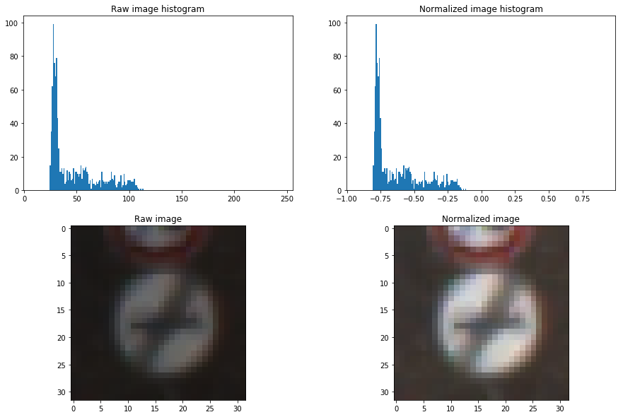

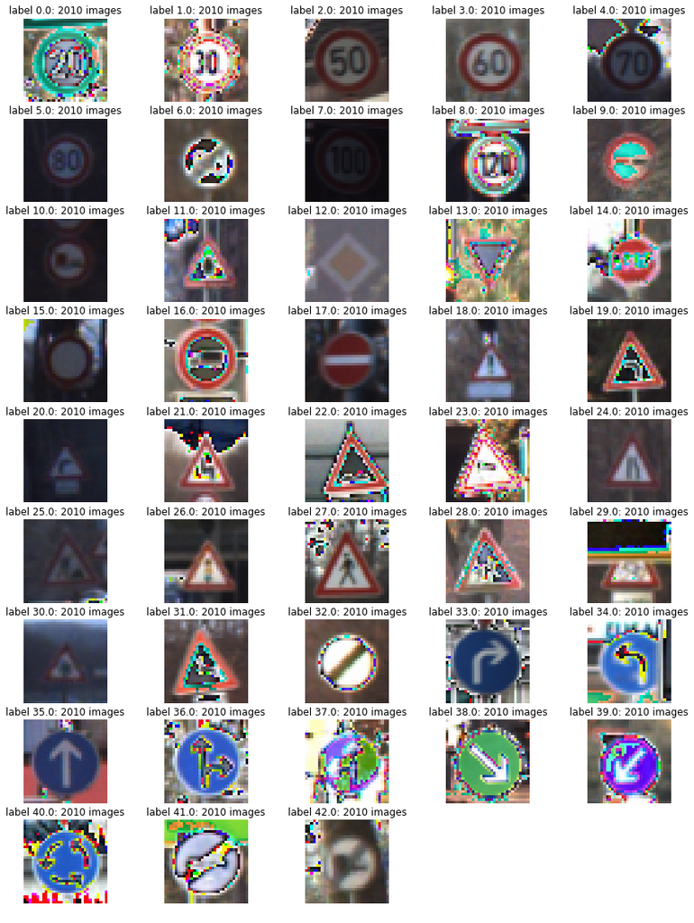

```
Number of training examples = 86430
Number of validation examples = 4410
Number of testing examples = 12630
Image data shape = (32, 32, 3)
Number of classes = 43
```

```python
ts_data = TrafficSignData.TrafficSignData(demo_mode=True)
```

## Step 2: Design and Test a Model Architecture

Design and implement a deep learning model that learns to recognize traffic signs.

### Training setup

This is an example of how to setup and run a training using my NeuralNetwork framework. The training framework supports lists of arguments for each layer to be tested and will run a training for each permutation. Arguments that can be tested include layer sizes, filter shapes, activation functions etc, etc. Each NeuralNetworkOperation can also provide some default parameters to try given the number of permutions you want to try, and an arbitrary size of the operation given as a number in the range 0-1 where 0 is small and 1 is huge.

```python
training_list = [
    Conv2dOperation.get_training_options(max_n_permutations=1, layer_size=0.1, filter_shape=[[7, 7]],
                                         activation=[tf.nn.relu6]),
    MaxPoolOperation.get_training_options(max_n_permutations=1),
    Conv2dOperation.get_training_options(max_n_permutations=1, layer_size=0.3, filter_shape=[[6, 6]],
                                         activation=[tf.nn.elu]),
    MaxPoolOperation.get_training_options(max_n_permutations=1),
    DenseOperation.get_training_options(max_n_permutations=1, layer_size=0.05, activation=[tf.nn.crelu]),
    DenseOperation.get_training_options(max_n_permutations=1, layer_size=0.01, activation=[tf.nn.sigmoid]),
    DropoutOperation.get_training_options(max_n_permutations=1)
]
```

### Running the training

The training list is feed to the TrafficSignTrainer, which then setup everything, including the NeuralNetworkGenerator producing each neural network graph to be tested. The training list showing all variants of each argument to be tested is displayed, and the total number of permutations needed is also printed.

```python
trainer = TrafficSignTrainer(training_list=training_list, epochs=30, batch_size=256, l2_regulizer_beta=0.,
                             learning_rate=0.0004)
trainer.train()
```

```
1. Conv2dOperation
                   n_output_channels                                  [15]
                        filter_shape                              [[7, 7]]
                             strides                              [(1, 1)]
                                  mu                                 [0.0]
                               sigma                                 [0.1]
                          activation  [<function relu6 at 0x7fb7b8d1db70>]
2. MaxPoolOperation
                      ksize  [[1, 2, 2, 1]]
                    strides  [[1, 2, 2, 1]]
3. Conv2dOperation
                   n_output_channels                                [49]
                        filter_shape                            [[6, 6]]
                             strides                            [(1, 1)]
                                  mu                               [0.0]
                               sigma                               [0.1]
                          activation  [<function elu at 0x7fb7b933db70>]
4. MaxPoolOperation
                      ksize  [[1, 2, 2, 1]]
                    strides  [[1, 2, 2, 1]]
5. DenseOperation
                  n_output_channels                                [4181]
                                 mu                                 [0.0]
                              sigma                                 [0.1]
                         activation  [<function crelu at 0x7fb7b8d1dae8>]
6. DenseOperation
                  n_output_channels                                   [811]
                                 mu                                   [0.0]
                              sigma                                   [0.1]
                         activation  [<function sigmoid at 0x7fb7b91d77b8>]
7. DropoutOperation
                    keep_prob  [0.5]

Total number of trainings: 1


Training (1/1): 20171017-055755
Conv2dOperation(name="op_1_Conv2dOperation", input_shape=[32, 32, 3], n_output_channels=15, filter_shape=[7, 7], strides=(1, 1), mu=0.0, sigma=0.1, activation=relu6)
MaxPoolOperation(name="op_2_MaxPoolOperation", input_shape=[26, 26, 15], ksize=[1, 2, 2, 1], strides=[1, 2, 2, 1])
Conv2dOperation(name="op_3_Conv2dOperation", input_shape=[13, 13, 15], n_output_channels=49, filter_shape=[6, 6], strides=(1, 1), mu=0.0, sigma=0.1, activation=elu)
MaxPoolOperation(name="op_4_MaxPoolOperation", input_shape=[8, 8, 49], ksize=[1, 2, 2, 1], strides=[1, 2, 2, 1])
DenseOperation(name="op_5_DenseOperation", input_shape=[4, 4, 49], n_output_channels=4181, mu=0.0, sigma=0.1, activation=crelu)
DenseOperation(name="op_6_DenseOperation", input_shape=[8362], n_output_channels=811, mu=0.0, sigma=0.1, activation=sigmoid)
DropoutOperation(name="op_7_DropoutOperation", input_shape=[811], keep_prob=0.5)
DenseOperation(name="op_8_DenseOperation", input_shape=[811], n_output_channels=43, mu=0.0, sigma=0.1, activation=None)
```

### Result analysis

#### Training summary

The result from each training processed by the TrafficSignTrainer is summarized in a log file:

```python
import pandas as pd
log_file = pd.read_csv("./training_output/log_file.csv")
log_file
```

|  | training-id | wall-time | cpu-time | epoch | accuracy | lowest precision | lowest sensitivity | lowest specificity | lowest f1 score | Unnamed: 9 |
| --- | --- | --- | --- | --- | --- | --- | --- | --- | --- | --- |
| 0 | 20171017-055755 | 151.6 | 148.0 | 24 | 0.9649 | 0.6833 | 0.7692 | 0.9957 | 0.8119 | NaN |

#### Detailed statistics

Each training also provide more detailed statistics for each class label.

```python
detailed_stat = pd.read_csv(f"./training_output/{log_file['training-id'][0]}/detailed_stat.csv")
detailed_stat
```

|  | Unnamed: 0 | Speed limit (20km/h) | Speed limit (30km/h) | Speed limit (50km/h) | Speed limit (60km/h) | Speed limit (70km/h) | Speed limit (80km/h) | End of speed limit (80km/h) | Speed limit (100km/h) | Speed limit (120km/h) | ... | Turn right ahead | Turn left ahead | Ahead only | Go straight or right | Go straight or left | Keep right | Keep left | Roundabout mandatory | End of no passing | End of no passing by vehicles over 3.5 metric tons |
| --- | --- | --- | --- | --- | --- | --- | --- | --- | --- | --- | --- | --- | --- | --- | --- | --- | --- | --- | --- | --- | --- |
| 0 | precision | 0.800000 | 0.958333 | 0.991667 | 0.966667 | 1.000000 | 0.928571 | 1.0 | 0.966667 | 0.946667 | ... | 1.000000 | 0.916667 | 1.000000 | 1.000000 | 1.0 | 0.990476 | 1.0 | 0.716667 | 0.733333 | 1.000000 |
| 1 | sensitivity | 0.923077 | 0.923695 | 0.933333 | 0.986395 | 0.958904 | 0.975000 | 1.0 | 0.947712 | 0.946667 | ... | 0.989011 | 1.000000 | 0.991736 | 0.983607 | 1.0 | 0.971963 | 1.0 | 0.955556 | 0.956522 | 0.967742 |
| 2 | specificity | 0.998631 | 0.997597 | 0.999519 | 0.998827 | 1.000000 | 0.996437 | 1.0 | 0.998825 | 0.998122 | ... | 1.000000 | 0.998852 | 1.000000 | 1.000000 | 1.0 | 0.999523 | 1.0 | 0.996105 | 0.998176 | 1.000000 |
| 3 | f1_score | 0.857143 | 0.940695 | 0.961616 | 0.976431 | 0.979021 | 0.951220 | 1.0 | 0.957096 | 0.946667 | ... | 0.994475 | 0.956522 | 0.995851 | 0.991736 | 1.0 | 0.981132 | 1.0 | 0.819048 | 0.830189 | 0.983607 |

4 rows × 44 columns

#### Confusion matrix

The detailed class statistics presented above is actually calculated from a confusion matrix, which also is stored to file.

```python
confusion_matrix = pd.read_csv(f"./training_output/{log_file['training-id'][0]}/confusion_matrix.csv")
confusion_matrix
```

|  | Unnamed: 0 | Speed limit (20km/h) | Speed limit (30km/h) | Speed limit (50km/h) | Speed limit (60km/h) | Speed limit (70km/h) | Speed limit (80km/h) | End of speed limit (80km/h) | Speed limit (100km/h) | Speed limit (120km/h) | ... | Turn left ahead | Ahead only | Go straight or right | Go straight or left | Keep right | Keep left | Roundabout mandatory | End of no passing | End of no passing by vehicles over 3.5 metric tons | TP + FN |
| --- | --- | --- | --- | --- | --- | --- | --- | --- | --- | --- | --- | --- | --- | --- | --- | --- | --- | --- | --- | --- | --- |
| 0 | Speed limit (20km/h) | 24.0 | 0.0 | 0.0 | 0.0 | 5.0 | 0.0 | 0.0 | 0.0 | 1.0 | ... | 0.0 | 0.0 | 0.0 | 0.0 | 0.0 | 0.0 | 0.0 | 0.0 | 0.0 | 30.0 |
| 1 | Speed limit (30km/h) | 0.0 | 230.0 | 7.0 | 1.0 | 2.0 | 0.0 | 0.0 | 0.0 | 0.0 | ... | 0.0 | 0.0 | 0.0 | 0.0 | 0.0 | 0.0 | 0.0 | 0.0 | 0.0 | 240.0 |
| 2 | Speed limit (50km/h) | 0.0 | 1.0 | 238.0 | 0.0 | 0.0 | 0.0 | 0.0 | 0.0 | 0.0 | ... | 0.0 | 0.0 | 0.0 | 0.0 | 0.0 | 0.0 | 0.0 | 0.0 | 0.0 | 240.0 |
| 3 | Speed limit (60km/h) | 0.0 | 0.0 | 0.0 | 145.0 | 0.0 | 3.0 | 0.0 | 1.0 | 1.0 | ... | 0.0 | 0.0 | 0.0 | 0.0 | 0.0 | 0.0 | 0.0 | 0.0 | 0.0 | 150.0 |
| 4 | Speed limit (70km/h) | 0.0 | 0.0 | 0.0 | 0.0 | 210.0 | 0.0 | 0.0 | 0.0 | 0.0 | ... | 0.0 | 0.0 | 0.0 | 0.0 | 0.0 | 0.0 | 0.0 | 0.0 | 0.0 | 210.0 |
| 5 | Speed limit (80km/h) | 0.0 | 3.0 | 9.0 | 0.0 | 0.0 | 195.0 | 0.0 | 0.0 | 0.0 | ... | 0.0 | 0.0 | 0.0 | 0.0 | 0.0 | 0.0 | 0.0 | 0.0 | 1.0 | 210.0 |
| 6 | End of speed limit (80km/h) | 0.0 | 0.0 | 0.0 | 0.0 | 0.0 | 0.0 | 60.0 | 0.0 | 0.0 | ... | 0.0 | 0.0 | 0.0 | 0.0 | 0.0 | 0.0 | 0.0 | 0.0 | 0.0 | 60.0 |
| 7 | Speed limit (100km/h) | 0.0 | 0.0 | 0.0 | 0.0 | 0.0 | 2.0 | 0.0 | 145.0 | 3.0 | ... | 0.0 | 0.0 | 0.0 | 0.0 | 0.0 | 0.0 | 0.0 | 0.0 | 0.0 | 150.0 |
| 8 | Speed limit (120km/h) | 0.0 | 0.0 | 0.0 | 0.0 | 1.0 | 0.0 | 0.0 | 7.0 | 142.0 | ... | 0.0 | 0.0 | 0.0 | 0.0 | 0.0 | 0.0 | 0.0 | 0.0 | 0.0 | 150.0 |
| 9 | No passing | 0.0 | 0.0 | 0.0 | 0.0 | 0.0 | 0.0 | 0.0 | 0.0 | 1.0 | ... | 0.0 | 0.0 | 0.0 | 0.0 | 0.0 | 0.0 | 0.0 | 0.0 | 0.0 | 150.0 |
| 10 | No passing for vehicles over 3.5 metric tons | 0.0 | 0.0 | 0.0 | 0.0 | 0.0 | 0.0 | 0.0 | 0.0 | 0.0 | ... | 0.0 | 0.0 | 0.0 | 0.0 | 0.0 | 0.0 | 0.0 | 0.0 | 0.0 | 210.0 |
| 11 | Right-of-way at the next intersection | 0.0 | 0.0 | 0.0 | 0.0 | 0.0 | 0.0 | 0.0 | 0.0 | 0.0 | ... | 0.0 | 0.0 | 0.0 | 0.0 | 0.0 | 0.0 | 0.0 | 0.0 | 0.0 | 150.0 |
| 12 | Priority road | 0.0 | 0.0 | 0.0 | 0.0 | 0.0 | 0.0 | 0.0 | 0.0 | 0.0 | ... | 0.0 | 0.0 | 0.0 | 0.0 | 0.0 | 0.0 | 0.0 | 0.0 | 0.0 | 210.0 |
| 13 | Yield | 0.0 | 0.0 | 0.0 | 0.0 | 0.0 | 0.0 | 0.0 | 0.0 | 0.0 | ... | 0.0 | 1.0 | 0.0 | 0.0 | 0.0 | 0.0 | 0.0 | 0.0 | 0.0 | 240.0 |
| 14 | Stop | 0.0 | 0.0 | 0.0 | 0.0 | 0.0 | 0.0 | 0.0 | 0.0 | 0.0 | ... | 0.0 | 0.0 | 0.0 | 0.0 | 0.0 | 0.0 | 0.0 | 0.0 | 0.0 | 90.0 |
| 15 | No vehicles | 0.0 | 0.0 | 0.0 | 0.0 | 0.0 | 0.0 | 0.0 | 0.0 | 0.0 | ... | 0.0 | 0.0 | 0.0 | 0.0 | 0.0 | 0.0 | 0.0 | 0.0 | 0.0 | 90.0 |
| 16 | Vehicles over 3.5 metric tons prohibited | 0.0 | 0.0 | 0.0 | 0.0 | 0.0 | 0.0 | 0.0 | 0.0 | 0.0 | ... | 0.0 | 0.0 | 0.0 | 0.0 | 0.0 | 0.0 | 0.0 | 0.0 | 0.0 | 60.0 |
| 17 | No entry | 0.0 | 0.0 | 0.0 | 0.0 | 0.0 | 0.0 | 0.0 | 0.0 | 0.0 | ... | 0.0 | 0.0 | 0.0 | 0.0 | 0.0 | 0.0 | 0.0 | 0.0 | 0.0 | 120.0 |
| 18 | General caution | 0.0 | 0.0 | 0.0 | 0.0 | 0.0 | 0.0 | 0.0 | 0.0 | 0.0 | ... | 0.0 | 0.0 | 1.0 | 0.0 | 0.0 | 0.0 | 0.0 | 0.0 | 0.0 | 120.0 |
| 19 | Dangerous curve to the left | 0.0 | 0.0 | 0.0 | 0.0 | 0.0 | 0.0 | 0.0 | 0.0 | 0.0 | ... | 0.0 | 0.0 | 0.0 | 0.0 | 0.0 | 0.0 | 0.0 | 0.0 | 0.0 | 30.0 |
| 20 | Dangerous curve to the right | 2.0 | 0.0 | 0.0 | 1.0 | 0.0 | 0.0 | 0.0 | 0.0 | 1.0 | ... | 0.0 | 0.0 | 0.0 | 0.0 | 0.0 | 0.0 | 0.0 | 0.0 | 0.0 | 60.0 |
| 21 | Double curve | 0.0 | 0.0 | 1.0 | 0.0 | 0.0 | 0.0 | 0.0 | 0.0 | 0.0 | ... | 0.0 | 0.0 | 0.0 | 0.0 | 0.0 | 0.0 | 0.0 | 0.0 | 0.0 | 60.0 |
| 22 | Bumpy road | 0.0 | 0.0 | 0.0 | 0.0 | 0.0 | 0.0 | 0.0 | 0.0 | 0.0 | ... | 0.0 | 0.0 | 0.0 | 0.0 | 0.0 | 0.0 | 0.0 | 0.0 | 0.0 | 60.0 |
| 23 | Slippery road | 0.0 | 0.0 | 0.0 | 0.0 | 0.0 | 0.0 | 0.0 | 0.0 | 0.0 | ... | 0.0 | 0.0 | 0.0 | 0.0 | 0.0 | 0.0 | 0.0 | 0.0 | 0.0 | 60.0 |
| 24 | Road narrows on the right | 0.0 | 0.0 | 0.0 | 0.0 | 1.0 | 0.0 | 0.0 | 0.0 | 1.0 | ... | 0.0 | 0.0 | 0.0 | 0.0 | 0.0 | 0.0 | 0.0 | 0.0 | 0.0 | 30.0 |
| 25 | Road work | 0.0 | 0.0 | 0.0 | 0.0 | 0.0 | 0.0 | 0.0 | 0.0 | 0.0 | ... | 0.0 | 0.0 | 0.0 | 0.0 | 0.0 | 0.0 | 0.0 | 0.0 | 0.0 | 150.0 |
| 26 | Traffic signals | 0.0 | 0.0 | 0.0 | 0.0 | 0.0 | 0.0 | 0.0 | 0.0 | 0.0 | ... | 0.0 | 0.0 | 0.0 | 0.0 | 0.0 | 0.0 | 0.0 | 0.0 | 0.0 | 60.0 |
| 27 | Pedestrians | 0.0 | 0.0 | 0.0 | 0.0 | 0.0 | 0.0 | 0.0 | 0.0 | 0.0 | ... | 0.0 | 0.0 | 0.0 | 0.0 | 0.0 | 0.0 | 0.0 | 0.0 | 0.0 | 30.0 |
| 28 | Children crossing | 0.0 | 0.0 | 0.0 | 0.0 | 0.0 | 0.0 | 0.0 | 0.0 | 0.0 | ... | 0.0 | 0.0 | 0.0 | 0.0 | 0.0 | 0.0 | 0.0 | 0.0 | 0.0 | 60.0 |
| 29 | Bicycles crossing | 0.0 | 0.0 | 0.0 | 0.0 | 0.0 | 0.0 | 0.0 | 0.0 | 0.0 | ... | 0.0 | 0.0 | 0.0 | 0.0 | 0.0 | 0.0 | 0.0 | 0.0 | 0.0 | 30.0 |
| 30 | Beware of ice/snow | 0.0 | 0.0 | 0.0 | 0.0 | 0.0 | 0.0 | 0.0 | 0.0 | 0.0 | ... | 0.0 | 0.0 | 0.0 | 0.0 | 0.0 | 0.0 | 0.0 | 0.0 | 0.0 | 60.0 |
| 31 | Wild animals crossing | 0.0 | 0.0 | 0.0 | 0.0 | 0.0 | 0.0 | 0.0 | 0.0 | 0.0 | ... | 0.0 | 0.0 | 0.0 | 0.0 | 0.0 | 0.0 | 0.0 | 0.0 | 0.0 | 90.0 |
| 32 | End of all speed and passing limits | 0.0 | 0.0 | 0.0 | 0.0 | 0.0 | 0.0 | 0.0 | 0.0 | 0.0 | ... | 0.0 | 0.0 | 0.0 | 0.0 | 0.0 | 0.0 | 0.0 | 0.0 | 0.0 | 30.0 |
| 33 | Turn right ahead | 0.0 | 0.0 | 0.0 | 0.0 | 0.0 | 0.0 | 0.0 | 0.0 | 0.0 | ... | 0.0 | 0.0 | 0.0 | 0.0 | 0.0 | 0.0 | 0.0 | 0.0 | 0.0 | 90.0 |
| 34 | Turn left ahead | 0.0 | 0.0 | 0.0 | 0.0 | 0.0 | 0.0 | 0.0 | 0.0 | 0.0 | ... | 55.0 | 0.0 | 0.0 | 0.0 | 5.0 | 0.0 | 0.0 | 0.0 | 0.0 | 60.0 |
| 35 | Ahead only | 0.0 | 0.0 | 0.0 | 0.0 | 0.0 | 0.0 | 0.0 | 0.0 | 0.0 | ... | 0.0 | 120.0 | 0.0 | 0.0 | 0.0 | 0.0 | 0.0 | 0.0 | 0.0 | 120.0 |
| 36 | Go straight or right | 0.0 | 0.0 | 0.0 | 0.0 | 0.0 | 0.0 | 0.0 | 0.0 | 0.0 | ... | 0.0 | 0.0 | 60.0 | 0.0 | 0.0 | 0.0 | 0.0 | 0.0 | 0.0 | 60.0 |
| 37 | Go straight or left | 0.0 | 0.0 | 0.0 | 0.0 | 0.0 | 0.0 | 0.0 | 0.0 | 0.0 | ... | 0.0 | 0.0 | 0.0 | 30.0 | 0.0 | 0.0 | 0.0 | 0.0 | 0.0 | 30.0 |
| 38 | Keep right | 0.0 | 0.0 | 0.0 | 0.0 | 0.0 | 0.0 | 0.0 | 0.0 | 0.0 | ... | 0.0 | 0.0 | 0.0 | 0.0 | 208.0 | 0.0 | 2.0 | 0.0 | 0.0 | 210.0 |
| 39 | Keep left | 0.0 | 0.0 | 0.0 | 0.0 | 0.0 | 0.0 | 0.0 | 0.0 | 0.0 | ... | 0.0 | 0.0 | 0.0 | 0.0 | 0.0 | 30.0 | 0.0 | 0.0 | 0.0 | 30.0 |
| 40 | Roundabout mandatory | 0.0 | 15.0 | 0.0 | 0.0 | 0.0 | 0.0 | 0.0 | 0.0 | 0.0 | ... | 0.0 | 0.0 | 0.0 | 0.0 | 1.0 | 0.0 | 43.0 | 1.0 | 0.0 | 60.0 |
| 41 | End of no passing | 0.0 | 0.0 | 0.0 | 0.0 | 0.0 | 0.0 | 0.0 | 0.0 | 0.0 | ... | 0.0 | 0.0 | 0.0 | 0.0 | 0.0 | 0.0 | 0.0 | 22.0 | 0.0 | 30.0 |
| 42 | End of no passing by vehicles over 3.5 metric ... | 0.0 | 0.0 | 0.0 | 0.0 | 0.0 | 0.0 | 0.0 | 0.0 | 0.0 | ... | 0.0 | 0.0 | 0.0 | 0.0 | 0.0 | 0.0 | 0.0 | 0.0 | 30.0 | 30.0 |
| 43 | TP + FP | 26.0 | 249.0 | 255.0 | 147.0 | 219.0 | 200.0 | 60.0 | 153.0 | 150.0 | ... | 55.0 | 121.0 | 61.0 | 30.0 | 214.0 | 30.0 | 45.0 | 23.0 | 31.0 | 4410.0 |

44 rows × 45 columns

### Model Architecture

My model is based on the LeNet-5 implementation shown in the classroom but with several changes.

#### Larger layers

Because the traffic signs have 3 channels (RGB) compared to 1 channel for the grayscale images in the lesson, I started of by scaling up all output channels by a factor of 3 compared to LeNet-5. The convolutional layers are also scaled up with larger filters.

#### L2 loss regulizer

I evaluated using L2 regulizer but in the end this gave worse result so the final network does not use this functionality (it's turned of by setting the L2_regulizer_beta argument to 0.

#### Dropout

Dropout showed positive effect on the result, so there is a dropout operation before the output layer with a keep probability of 0.5. I have not tried any other number for this argument (except no dropout).

#### Activation functions

I tried several activation functions for each layer, and finally ended up using different ones in each layer (relu6, elu, crelu and sigmoid).

### Neural-network operations

Each training provide a text file "NeuralNetworkOperations.txt" with code describing how to setup the graph used in the training. The file from the training above is shown below. This model architecture is also the best so far and the one I use for further evaluation with test data and additional traffic signs from the web.

```python
with open(f"./training_output/{log_file['training-id'][0]}/NeuralNetworkOperations.txt", 'r') as f:
    print(f.read())
```

```
Conv2dOperation(name="op_1_Conv2dOperation", input_shape=[32, 32, 3], n_output_channels=15, filter_shape=[7, 7], strides=(1, 1), mu=0.0, sigma=0.1, activation=relu6)
MaxPoolOperation(name="op_2_MaxPoolOperation", input_shape=[26, 26, 15], ksize=[1, 2, 2, 1], strides=[1, 2, 2, 1])
Conv2dOperation(name="op_3_Conv2dOperation", input_shape=[13, 13, 15], n_output_channels=49, filter_shape=[6, 6], strides=(1, 1), mu=0.0, sigma=0.1, activation=elu)
MaxPoolOperation(name="op_4_MaxPoolOperation", input_shape=[8, 8, 49], ksize=[1, 2, 2, 1], strides=[1, 2, 2, 1])
DenseOperation(name="op_5_DenseOperation", input_shape=[4, 4, 49], n_output_channels=4181, mu=0.0, sigma=0.1, activation=crelu)
DenseOperation(name="op_6_DenseOperation", input_shape=[8362], n_output_channels=811, mu=0.0, sigma=0.1, activation=sigmoid)
DropoutOperation(name="op_7_DropoutOperation", input_shape=[811], keep_prob=0.5)
DenseOperation(name="op_8_DenseOperation", input_shape=[811], n_output_channels=43, mu=0.0, sigma=0.1, activation=None)
```

### Test the Model

Copy the tensorflow files of the best model found to ./model/ before running the code below.

```python
tf.reset_default_graph()
x = tf.placeholder(tf.float32, (None, 32, 32, 3))
y = tf.placeholder(tf.int32, (None))

# Setup the neural network as described in training output.
nn = NeuralNetwork(x)
nn.add(Conv2dOperation, name="op_1_Conv2dOperation", n_output_channels=15, filter_shape=[7, 7], strides=(1, 1), mu=0.0, sigma=0.1, activation=tf.nn.relu6)
nn.add(MaxPoolOperation, name="op_2_MaxPoolOperation", ksize=[1, 2, 2, 1], strides=[1, 2, 2, 1])
nn.add(Conv2dOperation, name="op_3_Conv2dOperation", n_output_channels=49, filter_shape=[6, 6], strides=(1, 1), mu=0.0, sigma=0.1, activation=tf.nn.elu)
nn.add(MaxPoolOperation, name="op_4_MaxPoolOperation", ksize=[1, 2, 2, 1], strides=[1, 2, 2, 1])
nn.add(DenseOperation, name="op_5_DenseOperation", n_output_channels=4181, mu=0.0, sigma=0.1, activation=tf.nn.crelu)
nn.add(DenseOperation, name="op_6_DenseOperation", n_output_channels=811, mu=0.0, sigma=0.1, activation=tf.nn.sigmoid)
nn.add(DropoutOperation, name="op_7_DropoutOperation", keep_prob=0.5)
nn.add(DenseOperation, name="op_8_DenseOperation", n_output_channels=43, mu=0.0, sigma=0.1, activation=None)

one_hot_y = tf.one_hot(y, 43)
correct_prediction = tf.equal(tf.argmax(nn.get_logits(), 1), tf.argmax(one_hot_y, 1))
accuracy_operation = tf.reduce_mean(tf.cast(correct_prediction, tf.float32))
batch_size = 256
saver = tf.train.Saver()
```

#### Training set

```python
total_accuracy = 0
with tf.Session() as sess:
    saver.restore(sess, tf.train.latest_checkpoint("./model/"))
    for offset in range(0, ts_data.n_train, batch_size):
        feed_dict = nn.get_feed_dict(training=False)
        feed_dict.update({x: ts_data.X_train[offset:offset + batch_size],
                          y: ts_data.y_train[offset:offset + batch_size]})
        accuracy = sess.run(accuracy_operation, feed_dict=feed_dict)
        total_accuracy += (accuracy * len(feed_dict[x]))

    print("Total accuracy in test set ", total_accuracy / ts_data.n_train)
```

```
INFO:tensorflow:Restoring parameters from ./model/tensor_flow_model
Total accuracy in test set  1.0
```

#### Validation set

```python
total_accuracy = 0
with tf.Session() as sess:
    saver.restore(sess, tf.train.latest_checkpoint("./model/"))
    for offset in range(0, ts_data.n_valid, batch_size):
        feed_dict = nn.get_feed_dict(training=False)
        feed_dict.update({x: ts_data.X_valid[offset:offset + batch_size],
                          y: ts_data.y_valid[offset:offset + batch_size]})
        accuracy = sess.run(accuracy_operation, feed_dict=feed_dict)
        total_accuracy += (accuracy * len(feed_dict[x]))

    print("Total accuracy in test set ", total_accuracy / ts_data.n_valid)
```

```
INFO:tensorflow:Restoring parameters from ./model/tensor_flow_model
Total accuracy in test set  0.961678004535
```

#### Test set

```python
total_accuracy = 0
with tf.Session() as sess:
    saver.restore(sess, tf.train.latest_checkpoint("./model/"))
    for offset in range(0, ts_data.n_test, batch_size):
        feed_dict = nn.get_feed_dict(training=False)
        feed_dict.update({x: ts_data.X_test[offset:offset + batch_size],
                          y: ts_data.y_test[offset:offset + batch_size]})
        accuracy = sess.run(accuracy_operation, feed_dict=feed_dict)
        total_accuracy += (accuracy * len(feed_dict[x]))

    print("Total accuracy in test set ", total_accuracy / ts_data.n_test)
```

```
INFO:tensorflow:Restoring parameters from ./model/tensor_flow_model
Total accuracy in test set  0.944259699271
```

## Step 3: Test a Model on New Images

Five additional German traffic signs has been downloaded from the web and tested with my model below. I did some manual pre-processing by cutting and scaling to 32x32x3 pixels as in the provided data sets.

```python
import pandas as pd
sign_names = pd.read_csv("./signnames.csv")
def label2sign_name(label):
    return sign_names['SignName'][label]
```

### Load and Output the Images

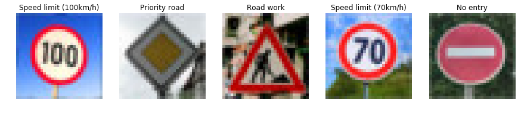

```python
import os
import matplotlib.image as mpimg
import matplotlib.pyplot as plt
additional_images = []
additional_labels = []
for file in os.listdir("./data/additional/"):
    additional_images.append(mpimg.imread(os.path.join("./data/additional", file)))
    additional_labels.append(int(file[len("label"):-(len(".jpg"))]))

plt.figure(figsize=(15, 10))
for idx, (image, label) in enumerate(zip(additional_images, additional_labels)):
    ax = plt.subplot(1, len(additional_images), idx + 1)
    ax.axis('off')
    ax.set_title(label2sign_name(label))
    ax.imshow(image)

plt.show()
```

### Predict the Sign Type for Each Image

#### Pre-process

A hack to use the normalization function in the TrafficSignData module.

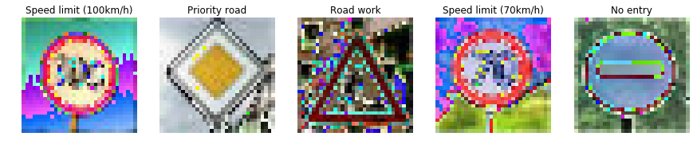

```python
normalized_images = ts_data._normalize_images(additional_images)
plt.figure(figsize=(15, 10))
for idx, (image, label) in enumerate(zip(normalized_images, additional_labels)):
    ax = plt.subplot(1, len(additional_images), idx + 1)
    ax.axis('off')
    ax.set_title(label2sign_name(label))
    ax.imshow(image)

plt.show()
```

### Analyze Performance

```python
with tf.Session() as sess:
    saver.restore(sess, tf.train.latest_checkpoint("./model/"))
    feed_dict = nn.get_feed_dict(training=False)
    feed_dict.update({x: normalized_images,
                      y: additional_labels})
    accuracy = sess.run(accuracy_operation, feed_dict=feed_dict)
    print("Accuracy on the additional images:", accuracy)
```

```
INFO:tensorflow:Restoring parameters from ./model/tensor_flow_model
Accuracy on the additional images: 1.0
```

### Output Top 5 Softmax Probabilities For Each Image Found on the Web

```
INFO:tensorflow:Restoring parameters from ./model/tensor_flow_model
```

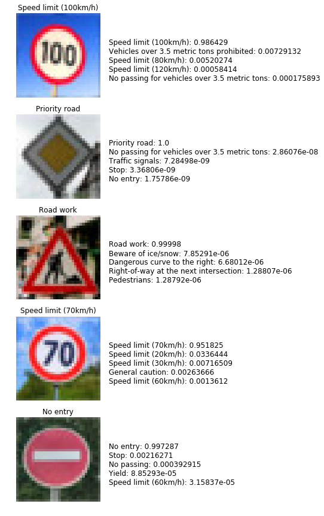

```python
logits = nn.get_logits()
pred_top5 = tf.nn.top_k(tf.div(logits, tf.reduce_sum(logits, 1)), k=5)

runnable = [logits, tf.reduce_sum(logits, 1), tf.div(logits, tf.reduce_sum(logits, 1)), pred_top5]
pred_top5 = tf.nn.top_k(tf.nn.softmax(nn.get_logits()), k=5)

with tf.Session() as sess:
    saver.restore(sess, tf.train.latest_checkpoint("./model/"))
    feed_dict = nn.get_feed_dict(training=False)
    feed_dict.update({x: normalized_images,
                      y: additional_labels})
    top5 = sess.run(tf.nn.top_k(tf.nn.softmax(nn.get_logits()), k=5), feed_dict=feed_dict)

plt.figure(figsize=(15, 15))
for idx, (image, label) in enumerate(zip(additional_images, additional_labels)):
    ax = plt.subplot(len(additional_images), 1, idx + 1)
    ax.axis('off')
    ax.set_title(label2sign_name(label))
    ax.imshow(image)
    data_str = ""
    for label, value in zip(top5.indices[idx], top5.values[idx]):
        data_str += label2sign_name(label) + ": " + str(value) + "\n"
    ax.text(1.1, 0.1, data_str, size=12, ha="left", transform=ax.transAxes)

plt.show()
```